# 4. Pythonを用いた基礎的なシングルセルRNA-seq解析

# pct_mt_counts: 各細胞のミトコンドリアのカウントのパーセント

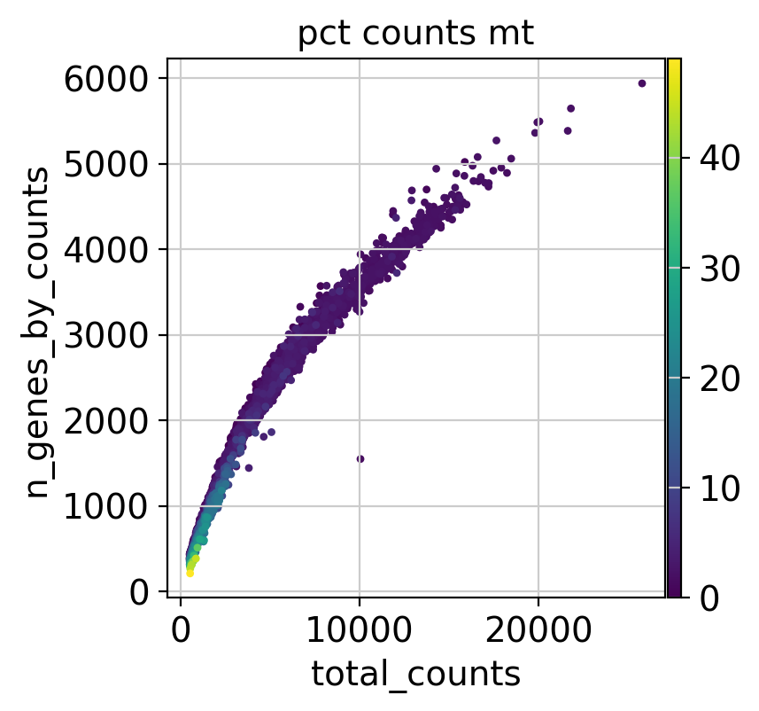

```python
sc.pl.scatter(adata, 'total_counts', 'n_genes_by_counts', color='pct_counts_mt', size=40)
```

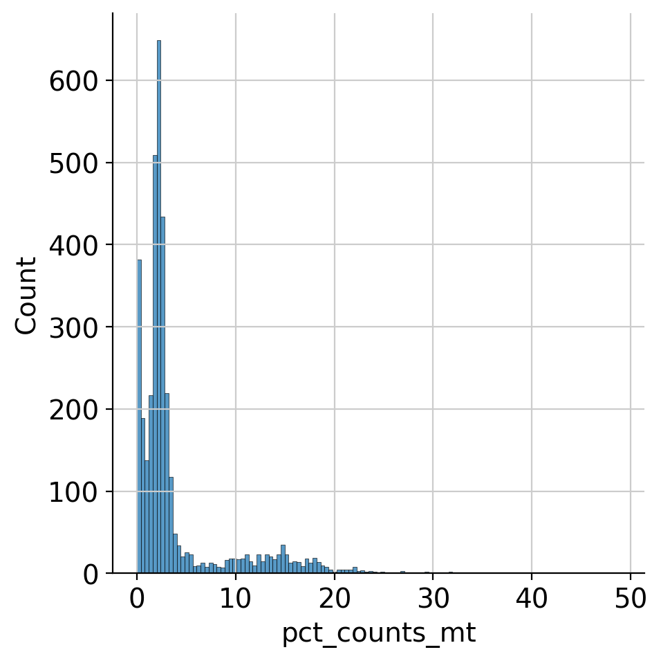

```python
fig = plt.figure()
sns.displot(adata.obs['pct_counts_mt'], kde=False)
plt.show()
```

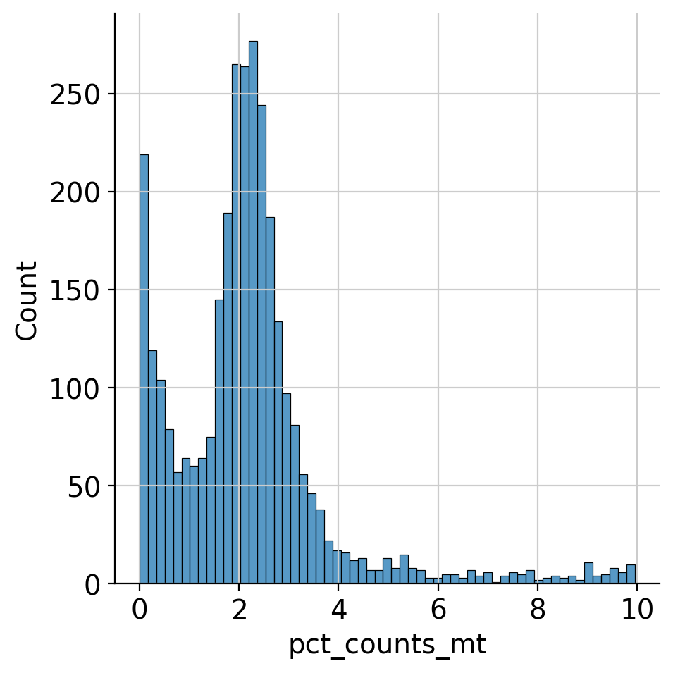

```python
fig = plt.figure()
sns.displot(adata.obs['pct_counts_mt'][adata.obs['pct_counts_mt'] < 10], kde=False)
plt.show()
```

分布を見て方針を決めて、フィルタリングを実行。

```python
print('Total number of cells: {:d}'.format(adata.n_obs))

# Total UMI count < 2000 の細胞をフィルタリング
sc.pp.filter_cells(adata, min_counts = 2000)
print('Number of cells after min count filter: {:d}'.format(adata.n_obs))

# Total UMI count > 13000 の細胞を除外（<=13000 を残す）ダブレット対策
sc.pp.filter_cells(adata, max_counts = 13000)
print('Number of cells after max count filter: {:d}'.format(adata.n_obs))

# 検出遺伝子数（その細胞でカウント>0の遺伝子数）が 1000 未満の細胞を除外（>=1000 を残す）
sc.pp.filter_cells(adata, min_genes = 1000)
print('Number of cells after gene filter: {:d}'.format(adata.n_obs))

# ミトコンドリア由来カウント割合（pct_counts_mt）が 6% 以上の細胞を除外（<6% を残す）
adata = adata[adata.obs['pct_counts_mt'] < 6]
print('Number of cells after MT filter: {:d}'.format(adata.n_obs))
```

```
Total number of cells: 3604
Number of cells after min count filter: 2639
Number of cells after max count filter: 2512
Number of cells after gene filter: 2509
Number of cells after MT filter: 2409
```

```python
adata
```

```
View of AnnData object with n_obs × n_vars = 2409 × 14026
    obs: 'n_genes', 'n_genes_by_counts', 'total_counts', 'total_counts_mt', 'pct_counts_mt', 'n_counts'
    var: 'gene_ids', 'feature_types', 'n_cells', 'mt', 'n_cells_by_counts', 'mean_counts', 'pct_dropout_by_counts', 'total_counts'
```

3606 細胞 × 33696 遺伝子 -> 3604 細胞 × 14026 遺伝子 -> 2409 細胞 × 14026 遺伝子

正規化や対数変換などの前に、この段階のカウントマトリックスを別のレイヤーに退避させておく。後工程で必要になる場合がある。レイヤーに保管したデータは基本的に以降の操作の影響を受けないが、細胞や遺伝子のslicing (特定の細胞（行）や遺伝子（列）だけを選んで部分集合にする操作) は適用されるので注意。（常にマトリックスのshapeは一致する）

```python
adata.layers['counts'] = adata.X.copy()
```

## 正規化

ライブラリサイズによる正規化、対数変換などの前処理は、scanpy.pp以下にいくつか便利な関数がある。

ここでは、細胞ごとのカウントの和が10,000になるように正規化してから、対数変換。

```python
sc.pp.normalize_per_cell(adata, counts_per_cell_after=1e4)
sc.pp.log1p(adata)
```

この段階のデータ（いろいろとややこしい変換をしていない「ピュア」なデータ）も、あとでプロットや結果解釈のときに使いたいので退避させておく。rawは特別なレイヤーで、数値だけでなくobsやvarのメタデータも含めてフリーズしてくれる。また遺伝子側のsliceの影響を受けない（細胞側のsliceは適用される）

```python
adata.raw = adata.copy()
```

## 特徴量選択（発現量の変動が大きい遺伝子）

発現量変動の大きい遺伝子のみを抽出して、データのサイズを小さくする。

発現量変動の大きい遺伝子とは、細胞間の発現量の分散が指定した値以上に大きい遺伝子を取得すればいいが、遺伝子の平均発現量毎に分散も異なるので、正規化分散をしてから特徴量選択をする。 seurat, cell_ranger, seurat_v3 のアルゴリズムが選択できる。 本講習ではデフォルトの seurat を使用する。

```python
sc.pp.highly_variable_genes?
```

[output not shown]

[output cut: 82 more lines]

[output not shown]

```python
# top 2000genes のみを抽出する
sc.pp.highly_variable_genes(adata, n_top_genes=2000, flavor='seurat')
print('\n','Number of highly variable genes: {:d}'.format(np.sum(adata.var['highly_variable'])))
```

```
 Number of highly variable genes: 2000
```

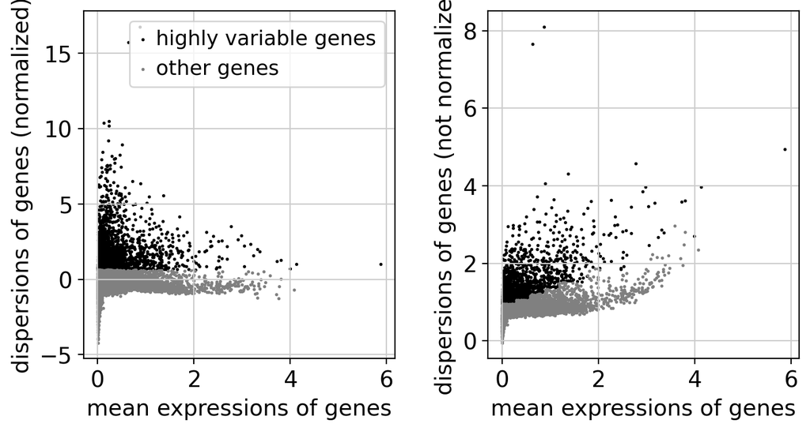

```python
sc.pl.highly_variable_genes(adata)
```

右 normalize なし：平均が増えるほど分散も増えるという“当たり前の関係”が見えている  
左 normalize あり：その関係を補正して、本当に相対的にばらつきが大きい遺伝子を見やすくしている

計算結果は自動的に adata.var 、つまり、遺伝子に関するメタデータを格納したオブジェクトに追加される。 highly_variable の項目が True の遺伝子が高発現変動遺伝子。

```python
adata.var
```

|  | gene_ids | feature_types | n_cells | mt | n_cells_by_counts | mean_counts | pct_dropout_by_counts | total_counts | highly_variable | means | dispersions | dispersions_norm |
| --- | --- | --- | --- | --- | --- | --- | --- | --- | --- | --- | --- | --- |
| Xkr4 | ENSMUSG00000051951 | Gene Expression | 1438 | False | 1438 | 1.294673 | 60.099889 | 4666.0 | True | 1.139496 | 1.740579 | 1.460650 |
| Gm1992 | ENSMUSG00000089699 | Gene Expression | 246 | False | 246 | 0.081299 | 93.174251 | 293.0 | False | 0.101559 | 0.863985 | 0.222981 |
| Gm19938 | ENSMUSG00000102331 | Gene Expression | 302 | False | 302 | 0.095727 | 91.620422 | 345.0 | False | 0.152147 | 0.776531 | -0.201676 |
| Mrpl15 | ENSMUSG00000033845 | Gene Expression | 1148 | False | 1148 | 0.418701 | 68.146504 | 1509.0 | False | 0.693607 | 0.733982 | -0.501883 |
| Lypla1 | ENSMUSG00000025903 | Gene Expression | 872 | False | 872 | 0.312708 | 75.804661 | 1127.0 | False | 0.556944 | 0.953352 | 0.228250 |
| ... | ... | ... | ... | ... | ... | ... | ... | ... | ... | ... | ... | ... |
| mt-Nd4 | ENSMUSG00000064363 | Gene Expression | 3128 | True | 3128 | 7.628746 | 13.207547 | 27494.0 | False | 2.574269 | 1.558975 | 0.153460 |
| mt-Nd5 | ENSMUSG00000064367 | Gene Expression | 1530 | True | 1530 | 0.652331 | 57.547170 | 2351.0 | False | 0.780986 | 0.861472 | -0.203398 |
| mt-Nd6 | ENSMUSG00000064368 | Gene Expression | 207 | True | 207 | 0.061598 | 94.256382 | 222.0 | False | 0.107539 | 0.764067 | -0.262201 |
| mt-Cytb | ENSMUSG00000064370 | Gene Expression | 3294 | True | 3294 | 16.334629 | 8.601554 | 58870.0 | False | 3.326169 | 2.138187 | 0.370356 |
| ENSMUSG00000095041 | ENSMUSG00000095041 | Gene Expression | 1021 | False | 1021 | 0.444229 | 71.670366 | 1601.0 | False | 0.585322 | 0.972779 | 0.303504 |

14026 rows × 12 columns

## 次元削減

主成分分析 (PCA) は、データ点全体の分布の大局的 (グローバル) な構造をよりよく表現する。 それに対して、t-SNE, UMAP は、どちらかというと局所的 (ローカル) な構造を重視する。高次元空間で近くに配置されている点を低次元空間でも近くに配置していく。その結果、どの細胞とどの細胞が似ているか、似ている細胞集団から構成されるクラスタがいくつあるのかといった生物学的な解釈に結びつけやすいので、scRNA-seq解析でよく使われている。しかしながら、クラスタ間の距離関係、このクラスターは、あっちのクラスターとどのくらい離れている、、とかはわからない。クラスタ間の距離の比較はできない。あくまで隣接している細胞同士の距離関係が最適化するように学習されている。

t-SNE のアルゴリズム  
高次元空間と低次元空間の距離関係を一致させて、どうやって比較するか？

1. 低次元側のデータ点の座標をランダムに (あるいは主成分分析やなんらかの高速な手法で暫定的に) 配置する
2. 高次元空間上の「距離」と低次元空間上の「距離」を計測するための関数を設定する
3. 高次元空間上の「距離」と低次元空間上の「距離」を比較して、誤差を表現する (コスト関数) を設定する
4. コスト関数をなんらかの最適化計算手法で最小化する

tSNE と比較した UMAP の利点

1. 計算の実行時間が tSNE より早い (が、実装によっては t-SNE も十分速い)
2. 大規模なデータセットでも t-SNE ほどメモリを消費せずにすむ
3. データ全体のグローバルな構造を tSNE よりもよく保存する (と言われている)
4. アルゴリズムが代数的位相幾何学の強固な理論的基盤に支えられている (?)

(独習Pythonバイオ情報解析 第11章 シングルセル解析② 次元削減 より)

t-SNE, UMAP ともに、計算効率のために、データの前処理として PCA を行って、特徴量の数を削減したセットを使用する。

## 主成分分析（PCA）

PCAはscanpyの前処理関数で簡単に実行できる。とりあえず、50次元まで落としてみる。 use_highly_variableのフラグをオンにすると、遺伝子全体ではなく前項で決定した高発現変動遺伝子のみを使って次元削減をする。

```python
sc.pp.pca(adata, n_comps=50, use_highly_variable=True, svd_solver='arpack')
```

PCAで落とした座標は、観察値のメタデータを格納する **obsm** に自動的に入る。obsm は Multi-dimensional annotation of observations の略。複数の次元でひとつの何かを表現するような観測値のメタデータがここに格納される。

```python
print(adata.obsm['X_pca'].shape)
```

```
(2409, 50)
```

プロットしてみる。Scanpyでは基本的に「前処理」（Preprocessing）に関わる関数がscanpy.ppに、「プロット」（Plot）に関わる関数がscanpy.plに入っている。

いまのところ特に色つけるようなデータも無いので、適当に細胞ごとのカウントで色分けをした。遺伝子名をcolorに指定するとその遺伝子の発現量によるプロットも可能。

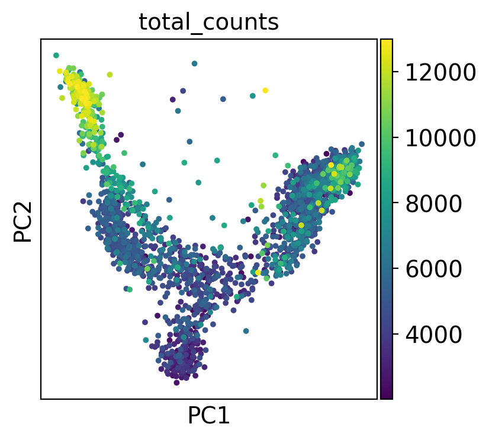

```python
sc.pl.pca(adata, color='total_counts')
```

遺伝子 Xkr4 の発現量による色付けの例

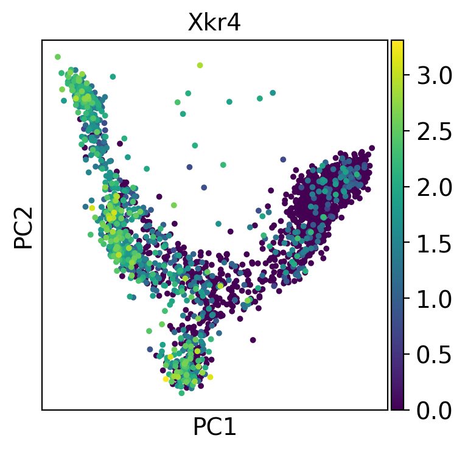

```python
sc.pl.pca(adata, color='Xkr4')
```

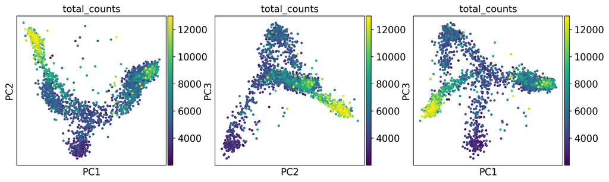

```python
sc.pl.pca(adata, color='total_counts',
          components=['1,2', '2,3', '1,3'])
```

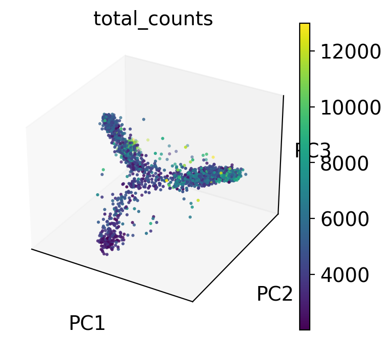

```python
# projection='3d'
# を指定すると3次元表示（見づらい）
sc.pl.pca(adata, color='total_counts', projection='3d')
```

寄与率をグラフで見る

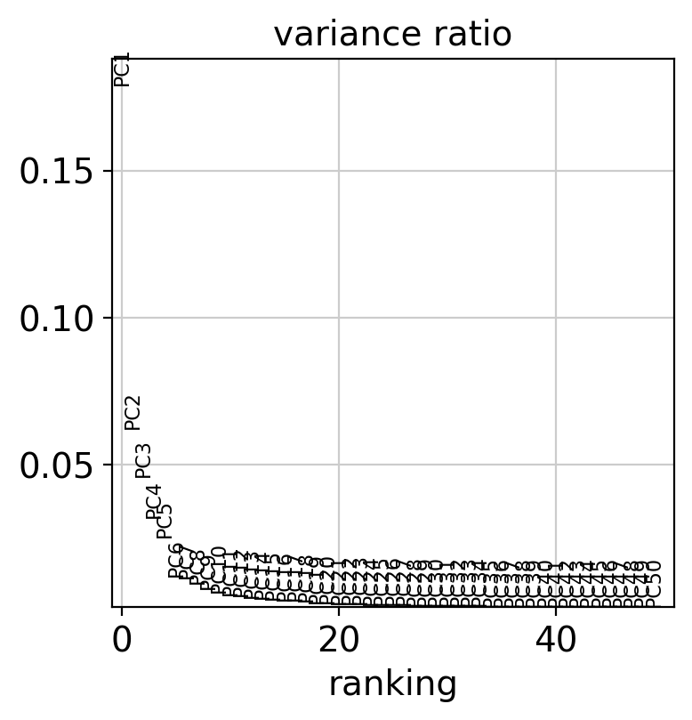

```python
sc.pl.pca_variance_ratio(adata, n_pcs=50)
```

## t分布型確率的近傍埋め込み（t-SNE）

まず、t-SNE, UMAP共通のステップとして、データから「近傍グラフ」（neighborhood graph）の構築が必要。

```python
sc.pp.neighbors(adata)
```

データ点間の接続関係（細胞の近傍関係）は、全細胞vs.全細胞のペアの情報を記録する **obsp** （Pairwise annotation of observations の略）に格納される。

```python
adata.obsp['connectivities']
```

```
<Compressed Sparse Row sparse matrix of dtype 'float32'
	with 49136 stored elements and shape (2409, 2409)>
```

接続関係を元にしてt-SNEを実行。

```python
sc.tl.tsne(adata)
```

t-SNE結果のプロット。

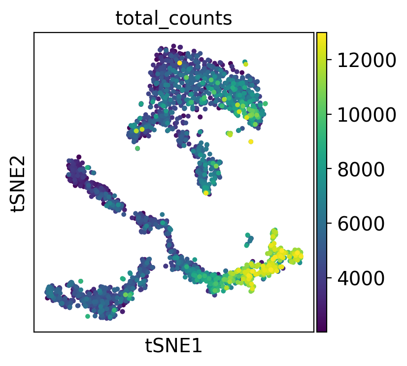

```python
sc.pl.tsne(adata, color='total_counts')
```

## UMAP

近傍グラフはすでに計算しているので、scanpy.tlのumap関数を使えばオーケー。

```python
sc.tl.umap(adata)
```

プロットはt-SNEとほとんど同じ。scanpy.pl以下にUMAP用の描画関数がある。

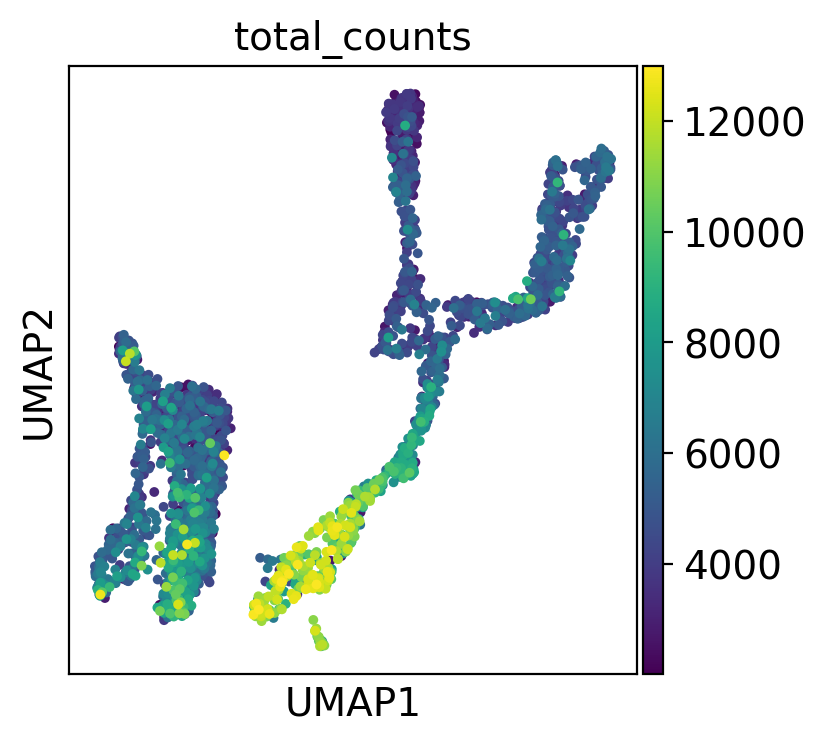

```python
sc.pl.umap(adata, color='total_counts')
```

## クラスタリング

### グラフベースのクラスタリング Leiden クラスタリング

高次空間のデータ点からK近傍グラフ構造を作成して、データ点のクラスタリングを、グラフのコミュニティ検出問題として扱う。グラフ構造から「コミュニティ (点のカタマリ、クラスタ)」を見つける。モジュラリティ:コミュニティへの割り当ての良さの指標。このモジュラリティが最大になるようなコミュニティ割り当てを目指す。

Leidenクラスタリングを実行してみる。モジュラリティの計算に影響を与える "resolution" パラメータが存在する。  
"resolution" は値が大きいほどクラスタが多くなる。default=1

```python
sc.tl.leiden(adata, resolution=0.5, key_added='leiden_r0.5')
```

クラスタリングの結果は観測値のメタデータ（obs）の中に格納される。

```python
adata.obs
```

|  | n_genes | n_genes_by_counts | total_counts | total_counts_mt | pct_counts_mt | n_counts | leiden_r0.5 |
| --- | --- | --- | --- | --- | --- | --- | --- |
| AAACCTGAGTGGACGT-1 | 3620 | 3620 | 10383.0 | 236.0 | 2.272946 | 10383.0 | 10 |
| AAACCTGGTCGAATCT-1 | 2321 | 2321 | 4994.0 | 115.0 | 2.302763 | 4994.0 | 2 |
| AAACCTGTCAGTCCCT-1 | 1428 | 1428 | 2485.0 | 47.0 | 1.891348 | 2485.0 | 4 |
| AAACCTGTCCAAACAC-1 | 3928 | 3928 | 11877.0 | 187.0 | 1.574472 | 11877.0 | 7 |
| AAACGGGCACTGAAGG-1 | 3021 | 3021 | 7538.0 | 127.0 | 1.684797 | 7538.0 | 6 |
| ... | ... | ... | ... | ... | ... | ... | ... |
| TTTGTCAAGGGCTCTC-1 | 3025 | 3025 | 7483.0 | 143.0 | 1.910998 | 7483.0 | 6 |
| TTTGTCACATCGATGT-1 | 2505 | 2505 | 5024.0 | 135.0 | 2.687102 | 5024.0 | 2 |
| TTTGTCAGTAGAGGAA-1 | 2590 | 2590 | 6611.0 | 176.0 | 2.662230 | 6611.0 | 5 |
| TTTGTCAGTCATCCCT-1 | 2400 | 2400 | 4935.0 | 121.0 | 2.451874 | 4935.0 | 4 |
| TTTGTCATCAGTTCGA-1 | 1610 | 1610 | 2835.0 | 54.0 | 1.904762 | 2835.0 | 2 |

2409 rows × 7 columns

プロットする点の座標じたいはUMAPの結果なので、プロットはUMAP版の関数を使い、色分けだけをクラスタリング結果で指定すればいい。

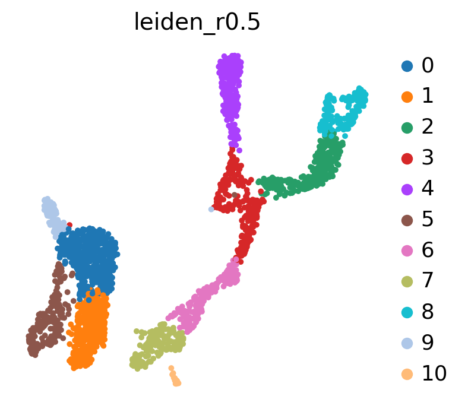

```python
sc.pl.umap(adata,
           color=['leiden_r0.5'],
           ncols=2,
           frameon=False)
```

```python
adata.write(filename='./data/retinal_1.h5ad')
```